# Phylogenetic Tree Inspection & Rooting

Maya Craig

2024-04-30

# Goals

1. Load the fastree unrooted tree.
2. Add tree to phyloseq object.
3. Visualize and inspect tree with ggtree.
4. Prune ASVs, if needed.
5. Root our tree.
6. Combine new tree with a phyloseq object.
7. Save 2 phyloseq objects: 1. Unrooted tree phyloseq object, 2. Rooted tree phyloseq object.

# Before you start

## Set my seed

```r
set.seed(98572)
```

## Load Packages

```r
pacman::p_load(tidyverse, phyloseq, ggtree, phytools,
               install = FALSE)
```

## Load Data files

```r
# Preprocessed phyloseq object
load("data/02_PreProcessing/raw_physeq.RData")
raw_physeq
```

```
## phyloseq-class experiment-level object
## otu_table()   OTU Table:         [ 4895 taxa and 41 samples ]
## sample_data() Sample Data:       [ 41 samples by 50 sample variables ]
## tax_table()   Taxonomy Table:    [ 4895 taxa by 9 taxonomic ranks ]
```

```r
# Load in the tree!
unrooted_tree <- read.tree("data/03_Phylogenetic_Tree/ASVs_unrooted.tree")
unrooted_tree
```

```
##
## Phylogenetic tree with 4895 tips and 4893 internal nodes.
##
## Tip labels:
##   ASV_4554, ASV_4367, ASV_4534, ASV_4599, ASV_1449, ASV_3374, ...
## Node labels:
##   , 0.670, 0.851, 0.945, 0.709, 0.489, ...
##
## Unrooted; includes branch lengths.
```

```r
str(unrooted_tree)
```

```
## List of 5
##  $ edge       : int [1:9787, 1:2] 4896 4897 4898 4899 4900 4901 4901 4902 4902 4903 ...
##  $ edge.length: num [1:9787] 0.0113 0.027 0.0422 0.028 0.0342 ...
##  $ Nnode      : int 4893
##  $ node.label : chr [1:4893] "" "0.670" "0.851" "0.945" ...
##  $ tip.label  : chr [1:4895] "ASV_4554" "ASV_4367" "ASV_4534" "ASV_4599" ...
##  - attr(*, "class")= chr "phylo"
##  - attr(*, "order")= chr "cladewise"
```

# Merge Phyloseq

```r
# Intuition check
stopifnot(ntaxa(raw_physeq) == ntaxa(unrooted_tree))

# Merge the tree with the phyloseq object
unrooted_physeq <-
  merge_phyloseq(raw_physeq, unrooted_tree)
```

[output not shown]

```
## Also defined by 'tidytree'
```

[output not shown]

```
## Also defined by 'tidytree'
```

[output not shown]

```
## Also defined by 'tidytree'
```

[output not shown]

```
## Also defined by 'tidytree'
```

[output not shown]

```
## Also defined by 'tidytree'
```

[output not shown]

```
## Also defined by 'tidytree'
```

[output not shown]

```
## Also defined by 'tidytree'
```

```r
unrooted_physeq
```

```
## phyloseq-class experiment-level object
## otu_table()   OTU Table:         [ 4895 taxa and 41 samples ]
## sample_data() Sample Data:       [ 41 samples by 50 sample variables ]
## tax_table()   Taxonomy Table:    [ 4895 taxa by 9 taxonomic ranks ]
## phy_tree()    Phylogenetic Tree: [ 4895 tips and 4893 internal nodes ]
```

# Plot Tree with `ggtree`

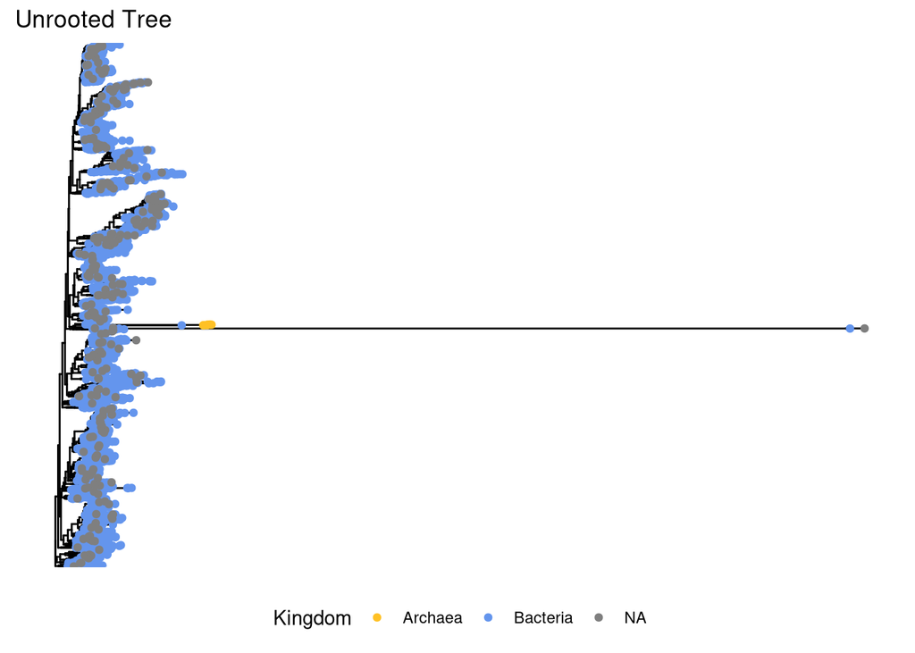

```r
# Make a basic tree
kingdom_tree <-
  ggtree(unrooted_physeq) +
  # color tips by kingdom
  geom_tippoint(mapping = aes(color = Kingdom)) +
  scale_color_manual(values = c("goldenrod1", "cornflowerblue", "grey")) +
  # Add title
  labs(title = "Unrooted Tree") +
  #move the legend to the bottom
  theme(legend.position = "bottom"); kingdom_tree
```

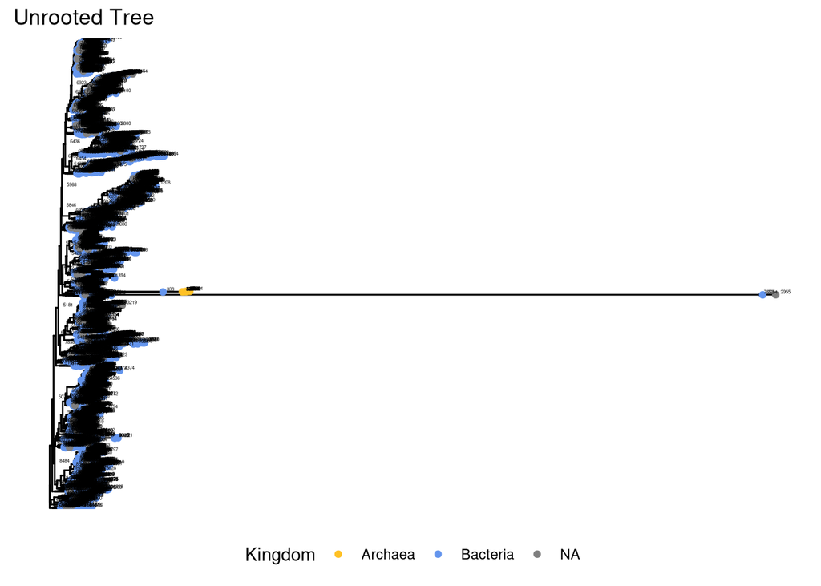

```r
kingdom_node_tree <-
  kingdom_tree +
  # Add the node label
  geom_text(aes(label=node), hjust= -0.5, vjust = -0.3, size = 1)
kingdom_node_tree
```

- It looks like there are two very long branches that need to be further investigated. There are also quite a few NAs.

# Evaluate Long Branch

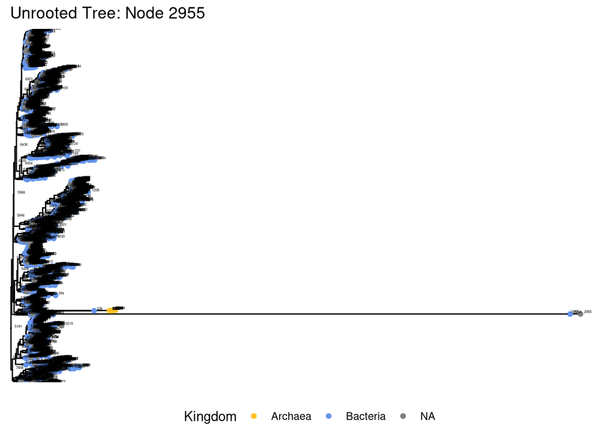

```r
# View a specific clade
viewClade(kingdom_node_tree +
          labs(title = "Unrooted Tree: Node 2955"),
          node = 5181)
```

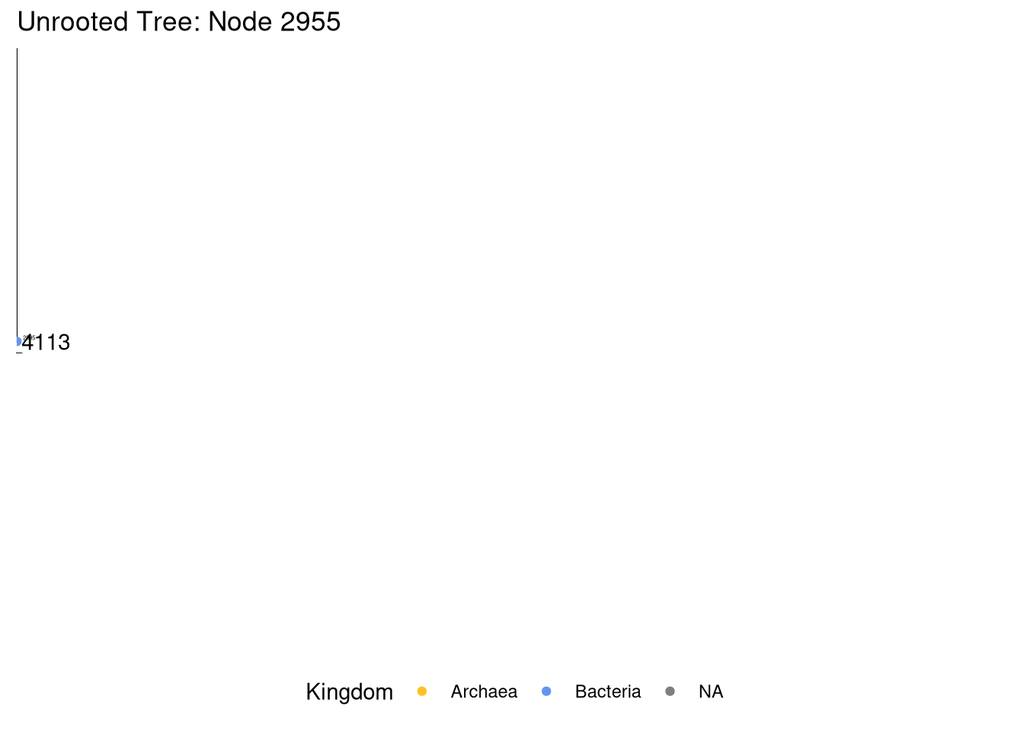

```r
viewClade(kingdom_node_tree +
          labs(title = "Unrooted Tree: Node 2955") +
          geom_text(aes(label=ASV)),
          node = 2995)
```

```r
#Other clades that were investigating in attempt to isolate the suspicious outlier: 5181, 2995, 2846, 5846, 3658, 7854
```

- ASV 4113, 4452, and 4425 are outliers on the tree (Mar and I used iTol to further investigate the outliers because it was difficult to subset by clade here in RStudio)

```r
unrooted_physeq %>%
  subset_taxa(., ASV == "ASV_4113" | ASV == "ASV_4425" | ASV == "ASV_4452") %>%
  tax_table() %>%
  data.frame()
```

[output not shown]

```
## Also defined by 'tidytree'
```

[output not shown]

```
## Also defined by 'tidytree'
```

[output not shown]

```
## Also defined by 'tidytree'
```

[output not shown]

```
## Also defined by 'tidytree'
```

```
##           Kingdom     Phylum   Class                 Order
## ASV_4425 Bacteria       <NA>    <NA>                  <NA>
## ASV_4452     <NA>       <NA>    <NA>                  <NA>
## ASV_4113 Bacteria Firmicutes Bacilli Thermoactinomycetales
##                          Family          Genus Species      ASV
## ASV_4425                   <NA>           <NA>    <NA> ASV_4425
## ASV_4452                   <NA>           <NA>    <NA> ASV_4452
## ASV_4113 Thermoactinomycetaceae Kroppenstedtia    <NA> ASV_4113
##                                                                                                                                                                                                                                                                             ASVseq
## ASV_4425  CGCTCTTCCGATCTCATTTTGTGCCAGCAGCCGCGGTAATTAGATACCCGCGTAGTCCGC…
## ASV_4452 ACGCTCTTCCGATCTCATTTTGTGCCAGCCGCCGCGGTAATTAGATACCCTTGTAGTCCG…
## ASV_4113 CGGTAATACGTAGGTGGCAAGCGTTGTCCGGAATTATTGGGCGTAAAGCGCGCGCAGGCG…
```

```r
# Let's also check the counts of the ASV
unrooted_physeq %>%
  subset_taxa(., ASV == "ASV_4113" | ASV == "ASV_4425" | ASV == "ASV_4452") %>%
  otu_table() %>%
  data.frame() %>%
  colSums()
```

[output not shown]

[output not shown]

```
## Also defined by 'tidytree'
```

[output not shown]

```
## Also defined by 'tidytree'
```

[output not shown]

```
## Also defined by 'tidytree'
```

```
## SRR23008984 SRR23008985 SRR23008986 SRR23008987 SRR23008988 SRR23008989
##           0           0           0           0           0           0
## SRR23008990 SRR23008991 SRR23008992 SRR23008993 SRR23008994 SRR23008995
##           2           0           0           0           0           0
## SRR23008996 SRR23008997 SRR23008998 SRR23008999 SRR23009000 SRR23009001
##           0           0           0           0           0           0
## SRR23009002 SRR23009003 SRR23009004 SRR23009005 SRR23009006 SRR23009007
##           0           0           0           4           0           0
## SRR23009008 SRR23009009 SRR23009010 SRR23009011 SRR23009012 SRR23009013
##           0           0           0           0           0           0
## SRR23009014 SRR23009015 SRR23009016 SRR23009017 SRR23009018 SRR23009019
##           0           0           0           0           0           0
## SRR23009020 SRR23009021 SRR23009023 SRR23009024 SRR23009025
##           0           0           0           0           0
```

ASV 4113 belongs to the Thermoactinomycetaceae Family and the Kroppenstedtia Genus. Two of this ASV is found in one sample (sample SRR23008990) but not found in any of the other samples. I will BLAST the sequence to find out more information!

After a BLAST search, I found that ASV 4113 matched an uncultured clone of Kloppenstedtia 16 rRNA gene with an E value of 4e-132 and a percent identify of 99.62%. This appears to be a contaminant, so this will be removed

The BLAST search showed that ASV_4425 belong to a carp (fish?) genome, this is probably a contaminate and will be removed.

The BLAST search showed that ASV_4452 100% identifty to a strain of coronavirus. This will be removed as well.

# Prune ASV_4425, ASV_4452, ASV_4113

```r
# Function from Joey McMurdie: https://github.com/joey711/phyloseq/issues/652
pop_taxa = function(physeq, badTaxa){
  allTaxa <-  taxa_names(physeq)
  allTaxa <- allTaxa[!(allTaxa %in% badTaxa)]
  return(prune_taxa(allTaxa, physeq))}

# Let's use the pop_taxa function :)
# Recreate a phyloseq object without ASV_4452, 4425, 4113
unrooted_physeq_rmASVs <-
  unrooted_physeq %>%
  pop_taxa(., c("ASV_4425","ASV_4452", "ASV_4113" ))
```

```
## Found more than one class "phylo" in cache; using the first, from namespace 'phyloseq'
```

```
## Also defined by 'tidytree'
```

```r
# Intuition Check
ntaxa(unrooted_physeq) - ntaxa(unrooted_physeq_rmASVs)
```

```
## [1] 3
```

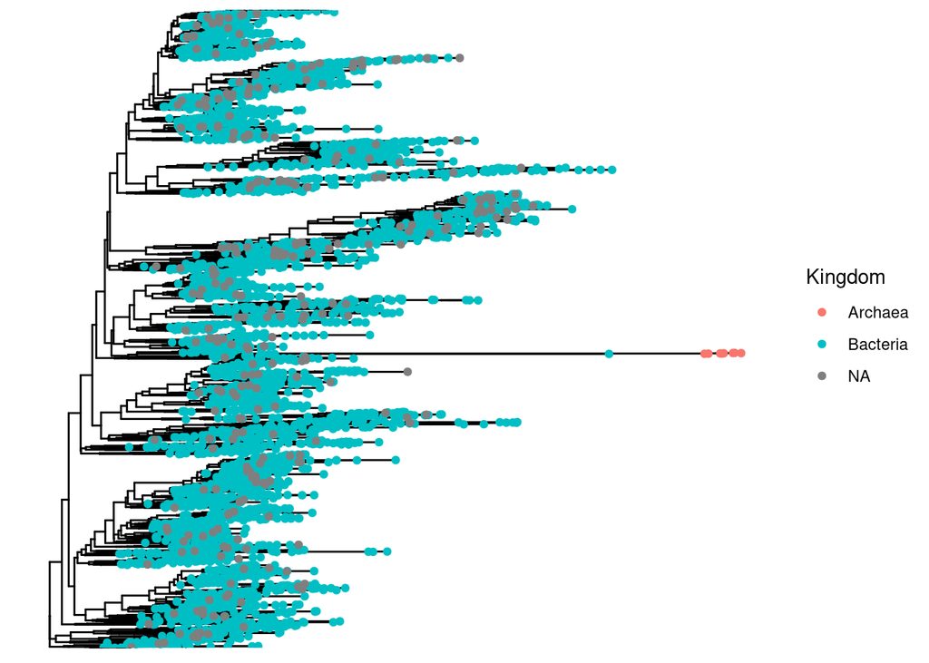

```r
# Visually inspect
ggtree(unrooted_physeq_rmASVs) +
  geom_tippoint(mapping = aes(color = Kingdom))
```

- After inspection, the outlier ASVs were successfully removed from the tree.

# Midroot Tree

```r
# Is the tree rooted?
new_unrooted_tree <-phy_tree(unrooted_physeq_rmASVs)
is.rooted(new_unrooted_tree)
```

```
## [1] FALSE
```

```r
# Let's midpoint root the tree
midpoint_rooted_tree <- midpoint.root(new_unrooted_tree)

# Is the new tree rooted?
is.rooted(midpoint_rooted_tree)
```

```
## [1] TRUE
```

```r
# Assign to a new phyloseq object: merging subsetted phyloseq with the new rooted tree

# 1. Create the phyloseq object without contaminated ASVs
physeq_rmASVs <-
  raw_physeq %>%
  subset_taxa(ASV != c("ASV_4425","ASV_4452","ASV_4113"))

# Merge tree with the new physeq_rm456
midroot_physeq_rmASVs <-
  merge_phyloseq(physeq_rmASVs, midpoint_rooted_tree)
```

[output not shown]

```
## Also defined by 'tidytree'
```

[output not shown]

```
## Also defined by 'tidytree'
```

[output not shown]

```
## Also defined by 'tidytree'
```

[output not shown]

```
## Also defined by 'tidytree'
```

```r
midroot_physeq_rmASVs
```

```
## phyloseq-class experiment-level object
## otu_table()   OTU Table:         [ 4892 taxa and 41 samples ]
## sample_data() Sample Data:       [ 41 samples by 50 sample variables ]
## tax_table()   Taxonomy Table:    [ 4892 taxa by 9 taxonomic ranks ]
## phy_tree()    Phylogenetic Tree: [ 4892 tips and 4891 internal nodes ]
```

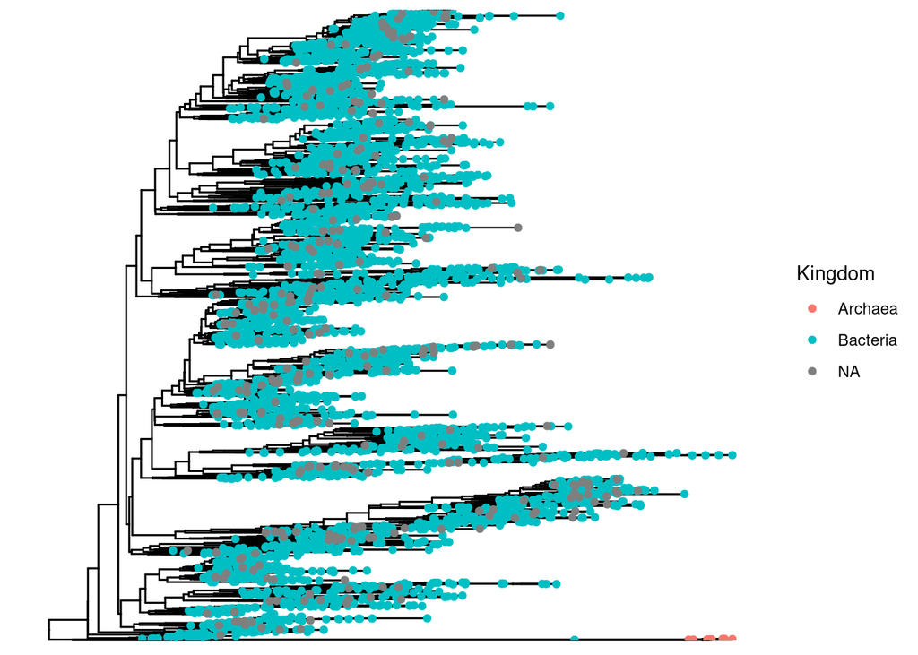

```r
# Quick inspection of tree
ggtree(midroot_physeq_rmASVs) +
  geom_tippoint(mapping = aes(color = Kingdom))
```

# Save to a new phyloseq object

```r
# Save phyloseq objects with our tree object to one .RData file
save(list = c("unrooted_physeq_rmASVs", "midroot_physeq_rmASVs"),
     file = "data/03_Phylogenetic_Tree/phytree_preprocessed_physeq.RData")
```

# Document conclusions

- The Bai et al paper did not asses phylogenetics and did not describe how contaminate ASVs were removed. In my analysis, I was able to successfully produce a phylogenetic tree using data that was aligned by MAFT and assembled by FastTree2.